# Step 1: Import Libraries

```python
# Import Libraries

import cv2
import os
import pickle
import numpy as np
import pandas as pd
from tqdm import tqdm
import tkinter as tk
from tkinter import filedialog
from IPython.display import Image
from matplotlib import pyplot as plt
from prettytable import PrettyTable
from astropy.table import Table, Column
from sklearn.preprocessing import StandardScaler
from sklearn.preprocessing import LabelEncoder
from sklearn.model_selection import train_test_split
from keras.models import Sequential
from keras.layers import Dense, Conv1D, Conv2D, Flatten
from keras.utils import to_categorical
from keras.models import load_model
import warnings; warnings.simplefilter('ignore')
pd.options.mode.chained_assignment = None
```

# Step 2: Load Sample Data

## Step 2.1: Load Training Data

```python
'''
*---------------------- LOAD_SAMPLE_DATA ------------------------*
|     Function: imread()                                         |
|             Purpose: Read an image as a numpy ndarray          |
|     Arguments:                                                 |
|             path: Complete path to image file                  |
|     Return:                                                    |
|             dataset: Numpy ndarray of pixel values             |
*----------------------------------------------------------------*
'''
path = ('Dataset/Training Data')
data = [os.path.join(dp, f) for dp, dn, filenames in os.walk(path) for f in filenames if (os.path.splitext(f)[1] == '.jpg' or os.path.splitext(f)[1] == '.png')]

training_data=[]

for image_name in tqdm(data):
    training_data.append((cv2.imread(image_name)))
```

```python
training_dataset = []
index=0
for i in data:
    if("apple" in i):
        training_dataset.append([training_data[index],"apple"])
    elif("bag" in i):
        training_dataset.append([training_data[index],"bag"])
    elif("circle" in i):
        training_dataset.append([training_data[index],"circle"])
    elif("door" in i):
        training_dataset.append([training_data[index],"door"])
    elif("eye" in i):
        training_dataset.append([training_data[index],"eye"])
    elif("flower" in i):
        training_dataset.append([training_data[index],"flower"])
    elif("glass" in i):
        training_dataset.append([training_data[index],"glass"])
    elif("house" in i):
        training_dataset.append([training_data[index],"house"])
    elif("ice cream" in i):
        training_dataset.append([training_data[index],"ice cream"])
    elif("jug" in i):
        training_dataset.append([training_data[index],"jug"])
    elif("kite" in i):
        training_dataset.append([training_data[index],"kite"])
    elif("leaf" in i):
        training_dataset.append([training_data[index],"leaf"])
    elif("mango" in i):
        training_dataset.append([training_data[index],"mango"])
    elif("net" in i):
        training_dataset.append([training_data[index],"net"])
    elif("number One" in i):
        training_dataset.append([training_data[index],"number One"])
    elif("pencil" in i):
        training_dataset.append([training_data[index],"pencil"])
    elif("letter Q" in i):
        training_dataset.append([training_data[index],"letter Q"])
    elif("rectangle" in i):
        training_dataset.append([training_data[index],"rectangle"])
    elif("star" in i):
        training_dataset.append([training_data[index],"star"])
    elif("triangle" in i):
        training_dataset.append([training_data[index],"triangle"])
    elif("umbrella" in i):
        training_dataset.append([training_data[index],"umbrella"])
    elif("vehicle" in i):
        training_dataset.append([training_data[index],"vehicle"])
    elif("watch" in i):
        training_dataset.append([training_data[index],"watch"])
    elif("letter X" in i):
        training_dataset.append([training_data[index],"letter X"])
    elif("letter y" in i):
        training_dataset.append([training_data[index],"letter y"])
    else:
        training_dataset.append([training_data[index],"letter z"])
    index=index+1
training_dataset=pd.DataFrame(training_dataset,columns=["Pixel Values","Label"])
```

## Step 2.2: Load Testing Data

```python
'''
*---------------------- LOAD_SAMPLE_DATA ------------------------*
|     Function: imread()                                         |
|             Purpose: Read an image as a numpy ndarray          |
|     Arguments:                                                 |
|             path: Complete path to image file                  |
|     Return:                                                    |
|             dataset: Numpy ndarray of pixel values             |
*----------------------------------------------------------------*
'''
path = ('Dataset/Testing Data')
data = [os.path.join(dp, f) for dp, dn, filenames in os.walk(path) for f in filenames if (os.path.splitext(f)[1] == '.jpg' or os.path.splitext(f)[1] == '.png')]

testing_data=[]

for image_name in tqdm(data):
    testing_data.append((cv2.imread(image_name)))
```

```python
testing_dataset = []
index=0
for i in data:
    if("apple" in i):
        testing_dataset.append([testing_data[index],"apple"])
    elif("bag" in i):
        testing_dataset.append([testing_data[index],"bag"])
    elif("circle" in i):
        testing_dataset.append([testing_data[index],"circle"])
    elif("door" in i):
        testing_dataset.append([testing_data[index],"door"])
    elif("eye" in i):
        testing_dataset.append([testing_data[index],"eye"])
    elif("flower" in i):
        testing_dataset.append([testing_data[index],"flower"])
    elif("glass" in i):
        testing_dataset.append([testing_data[index],"glass"])
    elif("house" in i):
        testing_dataset.append([testing_data[index],"house"])
    elif("ice cream" in i):
        testing_dataset.append([testing_data[index],"ice cream"])
    elif("jug" in i):
        testing_dataset.append([testing_data[index],"jug"])
    elif("kite" in i):
        testing_dataset.append([testing_data[index],"kite"])
    elif("leaf" in i):
        testing_dataset.append([testing_data[index],"leaf"])
    elif("mango" in i):
        testing_dataset.append([testing_data[index],"mango"])
    elif("net" in i):
        testing_dataset.append([testing_data[index],"net"])
    elif("number One" in i):
        testing_dataset.append([testing_data[index],"number One"])
    elif("pencil" in i):
        testing_dataset.append([testing_data[index],"pencil"])
    elif("letter Q" in i):
        testing_dataset.append([testing_data[index],"letter Q"])
    elif("rectangle" in i):
        testing_dataset.append([testing_data[index],"rectangle"])
    elif("star" in i):
        testing_dataset.append([testing_data[index],"star"])
    elif("triangle" in i):
        testing_dataset.append([testing_data[index],"triangle"])
    elif("umbrella" in i):
        testing_dataset.append([testing_data[index],"umbrella"])
    elif("vehicle" in i):
        testing_dataset.append([testing_data[index],"vehicle"])
    elif("watch" in i):
        testing_dataset.append([testing_data[index],"watch"])
    elif("letter X" in i):
        testing_dataset.append([testing_data[index],"letter X"])
    elif("letter y" in i):
        testing_dataset.append([testing_data[index],"letter y"])
    else:
        testing_dataset.append([testing_data[index],"letter z"])
    index=index+1
testing_dataset=pd.DataFrame(testing_dataset,columns=["Pixel Values","Label"])
```

# Step 3: Understand and Pre-process Sample Data

## Step 3.1: Understand Training Data

```python
# Understand Sample Data

print("\n\nAttributes in Training Data:")
print("============================\n")

print(training_dataset.columns)

print("\n\nNumber of Instances in Training Data:",training_dataset["Label"].count())
print("==========================================\n")
```

```
Attributes in Training Data:
============================

Index(['Pixel Values', 'Label'], dtype='object')


Number of Instances in Training Data: 104
==========================================
```

## Step 3.2: Understand Testing Data

```python
# Understand Sample Data

print("\n\nAttributes in Testing Data:")
print("===========================\n")

print(testing_dataset.columns)

print("\n\nNumber of Instances in Testing Data:",testing_dataset["Label"].count())
print("=========================================\n")
```

```
Attributes in Testing Data:
===========================

Index(['Pixel Values', 'Label'], dtype='object')


Number of Instances in Testing Data: 26
=========================================
```

## Step 3.3: Pre-process Training Data

```python
for pixels in enumerate(training_dataset["Pixel Values"]):
    training_dataset["Pixel Values"][pixels[0]]=cv2.resize(pixels[1],(45,45),interpolation=cv2.INTER_AREA)
print("\n\nPre-processed Training Data:")
print("============================\n")
```

```
Pre-processed Training Data:
============================
```

## Step 3.4: Pre-process Testing Data

```python
for pixels in enumerate(testing_dataset["Pixel Values"]):
    testing_dataset["Pixel Values"][pixels[0]]=cv2.resize(pixels[1],(45,45),interpolation=cv2.INTER_AREA)
print("\n\nPre-processed Testing Data:")
print("===========================\n")
```

```
Pre-processed Testing Data:
===========================
```

# Step 4: Convert Output to Machine Understandable Format (Numerical Representation) using Label Encoding Approach

## Step 4.1: Train the Label Encoder

```python
# Train the Label Encoder

'''
*------------------ TRAIN_LABEL_ENCODER --------------------*
|        Function: Fit()                                    |
|              Purpose: Fit or Train the Label Encoder      |
|        Arguments:                                         |
|               Labels: Target Values                       |
|        Return:                                            |
|               Instance: Returns an instance of self       |
*-----------------------------------------------------------*
'''

# Label
label = pd.DataFrame({"Label":["apple","bag","circle","door","eye","flower","glass","house","ice cream","jug","kite","leaf","mango","net","number One","pencil","letter Q","rectangle","star","triangle","star","triangle","umbrella","vehicle","watch","letter X","letter y","letter z"]})
label_encoder = LabelEncoder()

# Train the Label Encoders
label_encoder.fit(np.ravel(label))
```

```
LabelEncoder()
```

## Step 4.2: Convert Output of Training Data to Machine Understandable Format (Numerical Representation) using Label Encoder (Trained in Step 4.1)

```python
# Label Encoding of the Output

'''
*------------------ LABEL_ENCODE_OUTPUT --------------------*
|        Function: Transform()                              |
|              Purpose: Transform Input (Categorical)       |
|                       into Numerical Representation       |
|        Arguments:                                         |
|              Attribute: Target values                     |
|        Return:                                            |
|              Attribute: Numerical Representation          |
*-----------------------------------------------------------*
'''

training_data_encoded_output = training_dataset.copy()
original_training_data = training_dataset.copy()

# Transform Output of into Numerical Representation
print("\n\nLabel Attribute After Label Encoding:")
print("=====================================\n")
training_dataset["Encoded_Label"] = label_encoder.transform(training_dataset['Label'])
pd.set_option('max_rows', 104)
print(training_dataset[["Label", "Encoded_Label"]])
training_data_encoded_output[['Pixel Values', 'Label']] = training_dataset[['Pixel Values', 'Encoded_Label']]
```

```
Label Attribute After Label Encoding:
=====================================

         Label  Encoded_Label
0        apple              0
1        apple              0
2        apple              0
3        apple              0
4          bag              1
5          bag              1
6          bag              1
7          bag              1
8       circle              2
9       circle              2
10      circle              2
```

[output cut: 93 more lines]

## Step 4.3: Convert Output of Testing Data to Machine Understandable Format (Numerical Representation) using Label Encoder (Trained in Step 4.1)

```python
# Label Encoding of the Output

'''
*------------------ LABEL_ENCODE_OUTPUT --------------------*
|        Function: Transform()                              |
|              Purpose: Transform Input (Categorical)       |
|                       into Numerical Representation       |
|        Arguments:                                         |
|              Attribute: Target values                     |
|        Return:                                            |
|              Attribute: Numerical Representation          |
*-----------------------------------------------------------*
'''

testing_data_encoded_output = testing_dataset.copy()
original_testing_data = testing_dataset.copy()

# Transform Output of into Numerical Representation
print("\n\nLabel Attribute After Label Encoding:")
print("=====================================\n")
testing_dataset["Encoded_Label"] = label_encoder.transform(testing_dataset['Label'])
pd.set_option('max_rows', 26)
print(testing_dataset[["Label", "Encoded_Label"]])
testing_data_encoded_output[['Pixel Values', 'Label']] = testing_dataset[['Pixel Values', 'Encoded_Label']]
```

```
Label Attribute After Label Encoding:
=====================================

        Label  Encoded_Label
0       apple              0
1         bag              1
2      circle              2
3        door              3
4         eye              4
5      flower              5
6       glass              6
7       house              7
8   ice cream              8
9         jug              9
10       kite             10
11       leaf             11
12      mango             16
13        net             17
14   letter z             15
15     pencil             19
16   letter Q             12
17  rectangle             20
18       star             21
19   triangle             22
20   umbrella             23
21    vehicle             24
22      watch             25
23   letter X             13
24   letter y             14
25   letter z             15
```

# Step 5: Feature Extraction using Pixel Values based Approach (Converting Input to Machine Understandable Format (Numerical Representation))

#### Step 5.1: Extract Pixel Values based Features from Input (Image) of Training Data

```python
for pixels in enumerate(training_data_encoded_output["Pixel Values"]):
    training_data_encoded_output["Pixel Values"][pixels[0]]=pixels[1].flatten().tolist()
```

```python
print("\n\nPixel Values Extracted from Input of Training Data (Numerical Representation):")
print("=============================================================================\n")
print(training_data_encoded_output["Pixel Values"])
```

```
Pixel Values Extracted from Input of Training Data (Numerical Representation):
=============================================================================

0      [255, 255, 255, 255, 255, 255, 255, 255, 255, ...
1      [255, 255, 255, 255, 255, 255, 255, 255, 255, ...
2      [255, 255, 255, 255, 255, 255, 255, 255, 255, ...
3      [255, 255, 255, 255, 255, 255, 255, 255, 255, ...
4      [255, 255, 255, 255, 255, 255, 255, 255, 255, ...
                             ...
99     [255, 255, 255, 255, 255, 255, 255, 255, 255, ...
100    [255, 255, 255, 255, 255, 255, 255, 255, 255, ...
101    [255, 255, 255, 255, 255, 255, 255, 255, 255, ...
102    [255, 255, 255, 255, 255, 255, 255, 255, 255, ...
103    [255, 255, 255, 255, 255, 255, 255, 255, 255, ...
Name: Pixel Values, Length: 104, dtype: object
```

## Step 5.2: Extract Pixel Values based Features from Input (Image) of Testing Data

```python
for pixels in enumerate(testing_data_encoded_output["Pixel Values"]):
    testing_data_encoded_output["Pixel Values"][pixels[0]]=pixels[1].flatten().tolist()
```

```python
print("\n\nPixel Values Extracted from Input of Testing Data (Numerical Representation):")
print("=============================================================================\n")
print((testing_data_encoded_output["Pixel Values"]))
```

```
Pixel Values Extracted from Input of Testing Data (Numerical Representation):
=============================================================================

0     [255, 255, 255, 255, 255, 255, 255, 255, 255, ...
1     [255, 255, 255, 255, 255, 255, 255, 255, 255, ...
2     [255, 255, 255, 255, 255, 255, 255, 255, 255, ...
3     [255, 255, 255, 255, 255, 255, 255, 255, 255, ...
4     [255, 255, 255, 255, 255, 255, 255, 255, 255, ...
5     [255, 255, 255, 255, 255, 255, 255, 255, 255, ...
6     [255, 255, 255, 255, 255, 255, 255, 255, 255, ...
7     [255, 255, 255, 255, 255, 255, 255, 255, 255, ...
8     [255, 255, 255, 255, 255, 255, 255, 255, 255, ...
9     [255, 255, 255, 255, 255, 255, 255, 255, 255, ...
10    [255, 255, 255, 255, 255, 255, 255, 255, 255, ...
11    [255, 255, 255, 255, 255, 255, 255, 255, 255, ...
12    [255, 255, 255, 255, 255, 255, 255, 255, 255, ...
13    [255, 255, 255, 255, 255, 255, 255, 255, 255, ...
14    [255, 255, 255, 255, 255, 255, 255, 255, 255, ...
15    [255, 255, 255, 255, 255, 255, 255, 255, 255, ...
16    [255, 255, 255, 255, 255, 255, 255, 255, 255, ...
17    [255, 255, 255, 255, 255, 255, 255, 255, 255, ...
18    [255, 255, 255, 255, 255, 255, 255, 255, 255, ...
19    [255, 255, 255, 255, 255, 255, 255, 255, 255, ...
20    [255, 255, 255, 255, 255, 255, 255, 255, 255, ...
21    [255, 255, 255, 255, 255, 255, 255, 255, 255, ...
22    [255, 255, 255, 255, 255, 255, 255, 255, 255, ...
23    [255, 255, 255, 255, 255, 255, 255, 255, 255, ...
24    [255, 255, 255, 255, 255, 255, 255, 255, 255, ...
25    [255, 255, 255, 255, 255, 255, 255, 255, 255, ...
Name: Pixel Values, dtype: object
```

# Step 5.3: Saving Features in Excel / CSV Files

## Step 5.3.1 Saving Training Features in Excel File

```python
# Save Features
training_data_encoded_output.to_excel('Files/training-features.xlsx', index = False, header = True)
```

## Step 5.3.2 Saving Testing Features in Excel File

```python
# Save
testing_data_encoded_output.to_excel('Files/testing-features.xlsx', index = False, header = True)
```

# Step 6: Execute the Training Phase

## Step 6.1: Load Training Data in Machine Understandable Format (Numerical Representation) (Saved in Step 5.3.1)

```python
'''
*---------------------- LOAD_TRAINING_DATASET -------------------*
| Function : read_excel()                                        |
| Purpose : Read a dataset in Excel file format                  |
| Arguments :                                                    |
| path : Path to dataset file                                    |
| dataset : Dataset file name                                    |
| Return :                                                       |
| dataset : Dataset in DataFrame format                          |
*----------------------------------------------------------------*
'''

training_data = pd.read_excel(r'Files/training-features.xlsx')
for features in enumerate(training_data["Pixel Values"]):
    training_data["Pixel Values"][features[0]]=np.fromstring(features[1][1:-1], dtype=np.uint8, sep=',')
print("\n\nTraining Data:")
print("==============\n")
print(training_data)
```

```
Training Data:
==============

                                          Pixel Values  Label
0    [255, 255, 255, 255, 255, 255, 255, 255, 255, ...      0
1    [255, 255, 255, 255, 255, 255, 255, 255, 255, ...      0
2    [255, 255, 255, 255, 255, 255, 255, 255, 255, ...      0
3    [255, 255, 255, 255, 255, 255, 255, 255, 255, ...      0
4    [255, 255, 255, 255, 255, 255, 255, 255, 255, ...      1
..                                                 ...    ...
99   [255, 255, 255, 255, 255, 255, 255, 255, 255, ...     14
100  [255, 255, 255, 255, 255, 255, 255, 255, 255, ...     15
101  [255, 255, 255, 255, 255, 255, 255, 255, 255, ...     15
102  [255, 255, 255, 255, 255, 255, 255, 255, 255, ...     15
103  [255, 255, 255, 255, 255, 255, 255, 255, 255, ...     15

[104 rows x 2 columns]
```

## Step 6.2: Splitting Training Data into Input Feature Vectors and Outputs / Labels

```python
# Splitting Input Vectors and Outputs / Labels of Training Data

'''
*---------------- SPLIT_INPUT_VECTORS_AND_LABELS --------------*
|        Function: iloc()                                      |
|            Purpose: Splitting Input Vector and Labels        |
|        Arguments:                                            |
|            Attribute: Name or Location Attribute to Split    |
|        Return:                                               |
|            Attribute: Split Attributes                       |
*--------------------------------------------------------------*
'''

print("\n\nInputs Vectors (Feature Vectors) of Training Data:")
print("==================================================\n")
input_vector_train = training_data.iloc[: , :-1]
print(input_vector_train)

print("\n\nOutputs/Labels of Training Data:")
print("================================\n")
print("    Label")
output_label_train = training_data.iloc[: ,-1]
print(output_label_train)
```

```
Inputs Vectors (Feature Vectors) of Training Data:
==================================================

                                          Pixel Values
0    [255, 255, 255, 255, 255, 255, 255, 255, 255, ...
1    [255, 255, 255, 255, 255, 255, 255, 255, 255, ...
2    [255, 255, 255, 255, 255, 255, 255, 255, 255, ...
3    [255, 255, 255, 255, 255, 255, 255, 255, 255, ...
4    [255, 255, 255, 255, 255, 255, 255, 255, 255, ...
..                                                 ...
99   [255, 255, 255, 255, 255, 255, 255, 255, 255, ...
100  [255, 255, 255, 255, 255, 255, 255, 255, 255, ...
101  [255, 255, 255, 255, 255, 255, 255, 255, 255, ...
102  [255, 255, 255, 255, 255, 255, 255, 255, 255, ...
103  [255, 255, 255, 255, 255, 255, 255, 255, 255, ...

[104 rows x 1 columns]


Outputs/Labels of Training Data:
================================

    Label
0       0
1       0
2       0
3       0
4       1
       ..
99     14
100    15
101    15
102    15
103    15
Name: Label, Length: 104, dtype: int64
```

## Step 6.3: Train the Model

```python
# Train the Neural Network

print("\n\nTraining the Neural Network on Training Data")
print("=============================================\n")
input_train=np.zeros((len(input_vector_train["Pixel Values"]),6075),dtype=np.uint8)

for input_vector in enumerate(input_vector_train["Pixel Values"]):
    input_train[input_vector[0]]=input_vector[1]

X = input_train
Y = output_label_train

x_train, x_test, y_train, y_test = train_test_split(X, Y, test_size=0.3)

x_train = np.array(x_train)
y_train = np.array(y_train)
x_test = np.array(x_test)
y_test = np.array(y_test)

x_train = x_train.reshape(x_train.shape[0], 45, 45, 3)
x_test = x_test.reshape(x_test.shape[0], 45, 45, 3)

y_train = to_categorical(y_train)
y_test = to_categorical(y_test)

# Create Model
model = Sequential()

# Add Model layers
model.add(Conv2D(128, kernel_size=1, activation="relu", input_shape=(45, 45, 3)))
model.add(Conv2D(32, kernel_size=1, activation="relu"))
model.add(Flatten())
model.add(Dense(26, activation="softmax"))

# Compile model using accuracy to measure model performance
model.compile(optimizer='adam', loss='categorical_crossentropy', metrics=['accuracy'])

# Train the model
history = model.fit(x_train, y_train, validation_data=(x_test, y_test), epochs=50)
```

```
Training the Neural Network on Training Data
=============================================
```

```
Training and Validation Loss:
=============================
```

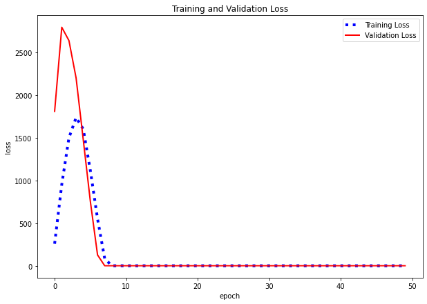

```python
# Summarize history for loss
print("\n\nTraining and Validation Loss:")
print("=============================\n")
fig = plt.gcf()
fig.set_size_inches(10, 7)
plt.plot(history.history['loss'] ,linewidth = 4, color="b", linestyle=':')
plt.plot(history.history['val_loss'],linewidth = 2, color="r")
plt.title('Training and Validation Loss')
plt.ylabel('loss')
plt.xlabel('epoch')
plt.legend(['Training Loss', 'Validation Loss'], loc='upper right')
plt.show()
```

```
Training and Validation Accuracy:
================================
```

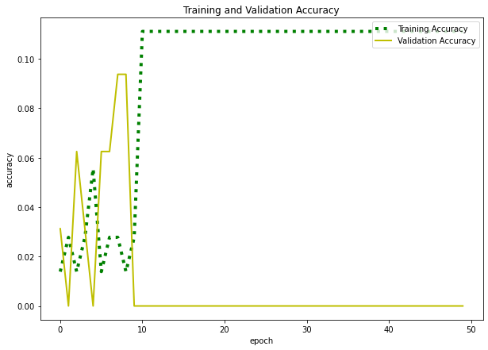

```python
# Summarize history for accuracy
print("\n\nTraining and Validation Accuracy:")
print("================================\n")
fig = plt.gcf()
fig.set_size_inches(10, 7)
plt.plot(history.history['accuracy'] ,linewidth = 4, color="g", linestyle=':')
plt.plot(history.history['val_accuracy'],linewidth = 2, color="y")
plt.title('Training and Validation Accuracy')
plt.ylabel('accuracy')
plt.xlabel('epoch')
plt.legend(['Training Accuracy', 'Validation Accuracy'], loc='upper right')
plt.show()
```

## Step 6.4: Save the Trained Model

```python
# Save the Trained Model

model.save('Trained_Model.h5')
print("\nTrained Model is Saved!!")
print("=========================\n")
```

```
Trained Model is Saved!!
=========================
```

# Step 7: Execute the Testing Phase

## Step 7.1: Load Testing Data in Machine Understander Format (Numerical Representation) (Saved in Step 5.3.2)

```python
'''
*---------------------- LOAD_TRAINING_DATASET -------------------*
| Function : read_excel()                                        |
| Purpose : Read a dataset in Excel file format                  |
| Arguments :                                                    |
| path : Path to dataset file                                    |
| dataset : Dataset file name                                    |
| Return :                                                       |
| dataset : Dataset in DataFrame format                          |
*----------------------------------------------------------------*
'''

testing_data = pd.read_excel(r'files/testing-features.xlsx')
for features in enumerate(testing_data["Pixel Values"]):
    testing_data["Pixel Values"][features[0]]=np.fromstring(features[1][1:-1], dtype=np.uint8, sep=',')
print("\n\nTesting Data:")
print("==============\n")
print(testing_data)
```

```
Testing Data:
==============

                                         Pixel Values  Label
0   [255, 255, 255, 255, 255, 255, 255, 255, 255, ...      0
1   [255, 255, 255, 255, 255, 255, 255, 255, 255, ...      1
2   [255, 255, 255, 255, 255, 255, 255, 255, 255, ...      2
3   [255, 255, 255, 255, 255, 255, 255, 255, 255, ...      3
4   [255, 255, 255, 255, 255, 255, 255, 255, 255, ...      4
5   [255, 255, 255, 255, 255, 255, 255, 255, 255, ...      5
6   [255, 255, 255, 255, 255, 255, 255, 255, 255, ...      6
7   [255, 255, 255, 255, 255, 255, 255, 255, 255, ...      7
8   [255, 255, 255, 255, 255, 255, 255, 255, 255, ...      8
9   [255, 255, 255, 255, 255, 255, 255, 255, 255, ...      9
10  [255, 255, 255, 255, 255, 255, 255, 255, 255, ...     10
11  [255, 255, 255, 255, 255, 255, 255, 255, 255, ...     11
12  [255, 255, 255, 255, 255, 255, 255, 255, 255, ...     16
13  [255, 255, 255, 255, 255, 255, 255, 255, 255, ...     17
14  [255, 255, 255, 255, 255, 255, 255, 255, 255, ...     15
15  [255, 255, 255, 255, 255, 255, 255, 255, 255, ...     19
16  [255, 255, 255, 255, 255, 255, 255, 255, 255, ...     12
17  [255, 255, 255, 255, 255, 255, 255, 255, 255, ...     20
18  [255, 255, 255, 255, 255, 255, 255, 255, 255, ...     21
19  [255, 255, 255, 255, 255, 255, 255, 255, 255, ...     22
20  [255, 255, 255, 255, 255, 255, 255, 255, 255, ...     23
21  [255, 255, 255, 255, 255, 255, 255, 255, 255, ...     24
22  [255, 255, 255, 255, 255, 255, 255, 255, 255, ...     25
23  [255, 255, 255, 255, 255, 255, 255, 255, 255, ...     13
24  [255, 255, 255, 255, 255, 255, 255, 255, 255, ...     14
25  [255, 255, 255, 255, 255, 255, 255, 255, 255, ...     15
```

## Step:7.2 Load the Model (Saved in Step 6.4)

```python
# Load the Saved Model

'''
*------------------- LOAD_SAVED_MODEL --------------------------*
|         Function: load()                                      |
|               Purpose: Method to Load Previously Saved Model  |
|         Arguments:                                            |
|               Model: Trained Model                            |
|         Return:                                               |
|               File: Saved Model will be Loaded in Memory      |
*---------------------------------------------------------------*
'''

# Load the Saved Model
model = load_model("Trained_Model.h5")
```

## Step 7.3: Evaluate the Machine Learning Model

### Step 7.3.1: Splitting Testing Data into Input Feature Vectors and Outputs / Labels

```python
# Splitting Input Vectors and Outputs/Labels of Testing Data

'''
*---------------- SPLIT_INPUT_VECTORS_AND_LABELS --------------*
|        Function: iloc()                                      |
|            Purpose: Splitting Input Vector and Labels        |
|        Arguments:                                            |
|            Attribute: Name or Location Attribute to Split    |
|        Return:                                               |
|            Attribute: Split Attributes                       |
*--------------------------------------------------------------*
'''

print("\n\nInputs Vectors (Feature Vectors) of Testing Data:")
print("=================================================\n")
input_vector_test = testing_data.iloc[: , :-1]
print(input_vector_test)
input_test=np.zeros((len(input_vector_test["Pixel Values"]),6075),dtype=np.uint8)

for input_vector in enumerate(input_vector_test["Pixel Values"]):
    input_test[input_vector[0]]=input_vector[1]
print("\n\nOutputs/Labels of Testing Data:")
print("==============================\n")
print("    Label")
output_label_test = testing_data.iloc[: ,-1]
print(output_label_test)
```

```
Inputs Vectors (Feature Vectors) of Testing Data:
=================================================

                                         Pixel Values
0   [255, 255, 255, 255, 255, 255, 255, 255, 255, ...
1   [255, 255, 255, 255, 255, 255, 255, 255, 255, ...
2   [255, 255, 255, 255, 255, 255, 255, 255, 255, ...
3   [255, 255, 255, 255, 255, 255, 255, 255, 255, ...
4   [255, 255, 255, 255, 255, 255, 255, 255, 255, ...
5   [255, 255, 255, 255, 255, 255, 255, 255, 255, ...
6   [255, 255, 255, 255, 255, 255, 255, 255, 255, ...
7   [255, 255, 255, 255, 255, 255, 255, 255, 255, ...
8   [255, 255, 255, 255, 255, 255, 255, 255, 255, ...
9   [255, 255, 255, 255, 255, 255, 255, 255, 255, ...
10  [255, 255, 255, 255, 255, 255, 255, 255, 255, ...
```

[output cut: 48 more lines]

### Step 7.3.2: Evaluate the Model (Make Predictions on Test Data)

```python
# Evaluate the Machine Learning Model
'''
*--------------------- EVALUATE_MACHINE_LEARNING_MODEL ----------------------*
|       Function: Predict()                                                  |
|             Purpose: Make a Prediction using Algorithm on Test Data        |
|       Arguments:                                                           |
|            Testing Data: Provide Test data to the Trained Model            |
|       Return:                                                              |
|            Predictions: Model return Predictions                           |
*----------------------------------------------------------------------------*
'''

# Provide Test data to the Trained Model

input_test = np.array(input_test)
output_label_test = np.array(output_label_test)

input_test = input_test.reshape(input_test.shape[0], 45, 45, 3)

model_predictions = model.predict(input_test)
model_predictions2 = model_predictions.copy()
testing_data.copy(deep=True)
pd.options.mode.chained_assignment = None
a=0
list = []
for i in model_predictions:
    model_predictions[a] = np.argmax(i)
    list.append(model_predictions[a][0].astype("int32"))
    a=a+1

testing_data["Predictions"] = list

list = testing_data
print("\n\nPredictions Returned by trained_model:")
print("======================================\n")
print(list)
```

```
Predictions Returned by trained_model:
======================================

                                         Pixel Values  Label  Predictions
0   [255, 255, 255, 255, 255, 255, 255, 255, 255, ...      0           15
1   [255, 255, 255, 255, 255, 255, 255, 255, 255, ...      1           15
2   [255, 255, 255, 255, 255, 255, 255, 255, 255, ...      2           15
3   [255, 255, 255, 255, 255, 255, 255, 255, 255, ...      3           15
4   [255, 255, 255, 255, 255, 255, 255, 255, 255, ...      4           15
5   [255, 255, 255, 255, 255, 255, 255, 255, 255, ...      5           15
6   [255, 255, 255, 255, 255, 255, 255, 255, 255, ...      6           15
7   [255, 255, 255, 255, 255, 255, 255, 255, 255, ...      7           15
8   [255, 255, 255, 255, 255, 255, 255, 255, 255, ...      8           15
9   [255, 255, 255, 255, 255, 255, 255, 255, 255, ...      9           15
10  [255, 255, 255, 255, 255, 255, 255, 255, 255, ...     10           15
11  [255, 255, 255, 255, 255, 255, 255, 255, 255, ...     11           15
12  [255, 255, 255, 255, 255, 255, 255, 255, 255, ...     16           15
13  [255, 255, 255, 255, 255, 255, 255, 255, 255, ...     17           15
14  [255, 255, 255, 255, 255, 255, 255, 255, 255, ...     15           15
15  [255, 255, 255, 255, 255, 255, 255, 255, 255, ...     19           15
16  [255, 255, 255, 255, 255, 255, 255, 255, 255, ...     12           15
17  [255, 255, 255, 255, 255, 255, 255, 255, 255, ...     20           15
18  [255, 255, 255, 255, 255, 255, 255, 255, 255, ...     21           15
19  [255, 255, 255, 255, 255, 255, 255, 255, 255, ...     22           15
20  [255, 255, 255, 255, 255, 255, 255, 255, 255, ...     23           15
21  [255, 255, 255, 255, 255, 255, 255, 255, 255, ...     24           15
22  [255, 255, 255, 255, 255, 255, 255, 255, 255, ...     25           15
23  [255, 255, 255, 255, 255, 255, 255, 255, 255, ...     13           15
24  [255, 255, 255, 255, 255, 255, 255, 255, 255, ...     14           15
25  [255, 255, 255, 255, 255, 255, 255, 255, 255, ...     15           15
```

### Step 7.3.3: Evaluate the Model (Calculate Accuracy Score)

```python
# Calculate the Accuracy Score

'''
/*------------------------ CALCULATE_ACCURACY_SCORE -------------------*
|          Function: accuracy_score()                                  |
|                Purpose: Evaluate the algorithm on Testing data       |
|          Arguments:                                                  |
|                Prediction: Predicted values                          |
|                Label: Actual values                                  |
|          Return:                                                     |
|                Accuracy: Accuracy Score                              |
*----------------------------------------------------------------------*
'''

# Calculate the Accuracy

from sklearn.metrics import accuracy_score
model_accuracy_score = accuracy_score(list["Label"],list["Predictions"])
```

[output not shown]

# Step 8: Execute the Application Phase

## Step 8.1: Take Input from User

```python
# Take Input from User

'''
*----------------------- TAKE_USER_INPUT ------------------------*
|     Function: imread()                                         |
|             Purpose: Read an image as a numpy ndarray          |
|     Arguments:                                                 |
|             path: Complete path to image file                  |
|     Return:                                                    |
|             dataset: Numpy ndarray of pixel values             |
*----------------------------------------------------------------*
'''
application_window = tk.Tk()
# Build a list of tuples for each file type the file dialog should display

my_filetypes = [('all files', '.*'), ('text files', '.txt')]

# Ask the user to select a single file name
user_file = filedialog.askopenfilename(parent=application_window,
                                    initialdir=os.getcwd(),
                                    title="Please select an Image to detect gender:",
                                    filetypes=my_filetypes)
application_window.destroy()
user_input=cv2.imread(user_file)
```

## Step 8.2: Convert User Input into Feature Vector using Pixel Values based Approach (Exactly Same as Feature Vectors of Training Data and Testing Data)

```python
# Convert User Input into Feature Vector
user_input = cv2.resize(user_input,(45,45),interpolation=cv2.INTER_AREA)
user_input = user_input.flatten()
print("\n\nUser Input Feature Vector:")
print("==========================\n")
print(user_input)
```

```
User Input Feature Vector:
==========================

[255 255 255 ... 255 255 255]
```

## Step 8.3: Make Prediction on Unseen Data

## Step 8.3.1: Load the Model (Saved in Step 6.4)

```python
# Load the Saved Model

'''
*----------------------- LOAD_SAVED_MODEL --------------------------*
|         Function: load()                                          |
|             Purpose: Method to Load Previously Saved Model        |
|         Arguments:                                                |
|               Model: Trained Model                                |
|         Return:                                                   |
|               File: Saved Model will be Loaded in Memory          |
*-------------------------------------------------------------------*
'''

# Load the Saved Model
model = load_model("Trained_Model.h5")
```

## Step 8.3.2: Apply Model on Feature Vector of Unseen Data

```python
# Prediction of Unseen Instance

'''
*----------------------------  MODEL_PREDICTION --------------------------*
|           Function: predict()                                           |
|                 Purpose: Use Trained Model to Predict the Output        |
|                          of Unseen Instances                            |
|           Arguments:                                                    |
|                 User Data: Label Encoded Feature Vector of              |
|                            Unseen Instances                             |
|           Return:                                                       |
|                 Survival: label                                         |
*-------------------------------------------------------------------------*
'''

# Make a Prediction on Unseen Data
user_input = np.array(user_input)
user_input = user_input.reshape(1, 45, 45, 3)
predicted_label = model.predict([user_input])
```

## Step 8.3.3: Return Prediction to the User

```python
predicted_label = np.argmax(predicted_label)
predicted_label = label_encoder.inverse_transform([predicted_label])

print("\n\n==============")
print(str(predicted_label[0][0].upper() + " : " + predicted_label))
print("==============\n\n")
```

```
==============
['L : letter z']
==============
```

# Step 9: Execute the Feedback Phase

## A Two-Step Process

### Step 01: After some time, take Feedback from

[output not shown]

### Step 02: Make a List of Possible Improvements based on Feedback received

# Step 10: Improve Model based on Feedback

### There is Always Room for Improvement

### Based on Feedback from Domain Experts and Users

```
o   Improve your Model
```

### ==========================================================

### ==========================================================